# Ford Go Bike Trip Data Exploration

## Introduction

This data set includes information about approximately 183,000 individual bike rides made in a bike-sharing system covering the greater San Francisco Bay area.

## Preliminary Wrangling

```python
# import all packages and set plots to be embedded inline
import numpy as np
import pandas as pd
import matplotlib.pyplot as plt
import seaborn as sb
import datetime as dt

%matplotlib inline
```

```python
# load in the dataset
bikedf = pd.read_csv('201902-fordgobike-tripdata.csv')
bikedf.head(10)
```

|  | duration_sec | start_time | end_time | start_station_id | start_station_name | start_station_latitude | start_station_longitude | end_station_id | end_station_name | end_station_latitude | end_station_longitude | bike_id | user_type | member_birth_year | member_gender | bike_share_for_all_trip |
| --- | --- | --- | --- | --- | --- | --- | --- | --- | --- | --- | --- | --- | --- | --- | --- | --- |
| 0 | 52185 | 2019-02-28 17:32:10.1450 | 2019-03-01 08:01:55.9750 | 21.0 | Montgomery St BART Station (Market St at 2nd St) | 37.789625 | -122.400811 | 13.0 | Commercial St at Montgomery St | 37.794231 | -122.402923 | 4902 | Customer | 1984.0 | Male | No |
| 1 | 42521 | 2019-02-28 18:53:21.7890 | 2019-03-01 06:42:03.0560 | 23.0 | The Embarcadero at Steuart St | 37.791464 | -122.391034 | 81.0 | Berry St at 4th St | 37.775880 | -122.393170 | 2535 | Customer | NaN | NaN | No |
| 2 | 61854 | 2019-02-28 12:13:13.2180 | 2019-03-01 05:24:08.1460 | 86.0 | Market St at Dolores St | 37.769305 | -122.426826 | 3.0 | Powell St BART Station (Market St at 4th St) | 37.786375 | -122.404904 | 5905 | Customer | 1972.0 | Male | No |
| 3 | 36490 | 2019-02-28 17:54:26.0100 | 2019-03-01 04:02:36.8420 | 375.0 | Grove St at Masonic Ave | 37.774836 | -122.446546 | 70.0 | Central Ave at Fell St | 37.773311 | -122.444293 | 6638 | Subscriber | 1989.0 | Other | No |
| 4 | 1585 | 2019-02-28 23:54:18.5490 | 2019-03-01 00:20:44.0740 | 7.0 | Frank H Ogawa Plaza | 37.804562 | -122.271738 | 222.0 | 10th Ave at E 15th St | 37.792714 | -122.248780 | 4898 | Subscriber | 1974.0 | Male | Yes |
| 5 | 1793 | 2019-02-28 23:49:58.6320 | 2019-03-01 00:19:51.7600 | 93.0 | 4th St at Mission Bay Blvd S | 37.770407 | -122.391198 | 323.0 | Broadway at Kearny | 37.798014 | -122.405950 | 5200 | Subscriber | 1959.0 | Male | No |
| 6 | 1147 | 2019-02-28 23:55:35.1040 | 2019-03-01 00:14:42.5880 | 300.0 | Palm St at Willow St | 37.317298 | -121.884995 | 312.0 | San Jose Diridon Station | 37.329732 | -121.901782 | 3803 | Subscriber | 1983.0 | Female | No |
| 7 | 1615 | 2019-02-28 23:41:06.7660 | 2019-03-01 00:08:02.7560 | 10.0 | Washington St at Kearny St | 37.795393 | -122.404770 | 127.0 | Valencia St at 21st St | 37.756708 | -122.421025 | 6329 | Subscriber | 1989.0 | Male | No |
| 8 | 1570 | 2019-02-28 23:41:48.7900 | 2019-03-01 00:07:59.7150 | 10.0 | Washington St at Kearny St | 37.795393 | -122.404770 | 127.0 | Valencia St at 21st St | 37.756708 | -122.421025 | 6548 | Subscriber | 1988.0 | Other | No |
| 9 | 1049 | 2019-02-28 23:49:47.6990 | 2019-03-01 00:07:17.0250 | 19.0 | Post St at Kearny St | 37.788975 | -122.403452 | 121.0 | Mission Playground | 37.759210 | -122.421339 | 6488 | Subscriber | 1992.0 | Male | No |

```python
# General column details
bikedf.info()
```

```
<class 'pandas.core.frame.DataFrame'>
RangeIndex: 183412 entries, 0 to 183411
Data columns (total 16 columns):
 #   Column                   Non-Null Count   Dtype
---  ------                   --------------   -----
 0   duration_sec             183412 non-null  int64
 1   start_time               183412 non-null  object
 2   end_time                 183412 non-null  object
 3   start_station_id         183215 non-null  float64
 4   start_station_name       183215 non-null  object
 5   start_station_latitude   183412 non-null  float64
 6   start_station_longitude  183412 non-null  float64
 7   end_station_id           183215 non-null  float64
 8   end_station_name         183215 non-null  object
 9   end_station_latitude     183412 non-null  float64
 10  end_station_longitude    183412 non-null  float64
 11  bike_id                  183412 non-null  int64
 12  user_type                183412 non-null  object
 13  member_birth_year        175147 non-null  float64
 14  member_gender            175147 non-null  object
 15  bike_share_for_all_trip  183412 non-null  object
dtypes: float64(7), int64(2), object(7)
memory usage: 22.4+ MB
```

```python
# the dataset has 183412 rows and 16 columns
bikedf.shape
```

```
(183412, 16)
```

```python
bikedf.describe()
```

|  | duration_sec | start_station_id | start_station_latitude | start_station_longitude | end_station_id | end_station_latitude | end_station_longitude | bike_id | member_birth_year |
| --- | --- | --- | --- | --- | --- | --- | --- | --- | --- |
| count | 183412.000000 | 183215.000000 | 183412.000000 | 183412.000000 | 183215.000000 | 183412.000000 | 183412.000000 | 183412.000000 | 175147.000000 |
| mean | 726.078435 | 138.590427 | 37.771223 | -122.352664 | 136.249123 | 37.771427 | -122.352250 | 4472.906375 | 1984.806437 |
| std | 1794.389780 | 111.778864 | 0.099581 | 0.117097 | 111.515131 | 0.099490 | 0.116673 | 1664.383394 | 10.116689 |
| min | 61.000000 | 3.000000 | 37.317298 | -122.453704 | 3.000000 | 37.317298 | -122.453704 | 11.000000 | 1878.000000 |
| 25% | 325.000000 | 47.000000 | 37.770083 | -122.412408 | 44.000000 | 37.770407 | -122.411726 | 3777.000000 | 1980.000000 |
| 50% | 514.000000 | 104.000000 | 37.780760 | -122.398285 | 100.000000 | 37.781010 | -122.398279 | 4958.000000 | 1987.000000 |
| 75% | 796.000000 | 239.000000 | 37.797280 | -122.286533 | 235.000000 | 37.797320 | -122.288045 | 5502.000000 | 1992.000000 |
| max | 85444.000000 | 398.000000 | 37.880222 | -121.874119 | 398.000000 | 37.880222 | -121.874119 | 6645.000000 | 2001.000000 |

```python
# Check for duplicates
bikedf.duplicated().sum()
```

```
0
```

### Data Cleaning

#### Missing values in start_station_id , start_station_name, end_station_id, end_station_name, member_birth_year and member_gender

```python
# drope rows with missing values
bikedf = bikedf.dropna()
# tests all columns with missing values have been dropped
bikedf.info()
```

```
<class 'pandas.core.frame.DataFrame'>
Int64Index: 174952 entries, 0 to 183411
Data columns (total 16 columns):
 #   Column                   Non-Null Count   Dtype
---  ------                   --------------   -----
 0   duration_sec             174952 non-null  int64
 1   start_time               174952 non-null  object
 2   end_time                 174952 non-null  object
 3   start_station_id         174952 non-null  float64
 4   start_station_name       174952 non-null  object
 5   start_station_latitude   174952 non-null  float64
 6   start_station_longitude  174952 non-null  float64
 7   end_station_id           174952 non-null  float64
 8   end_station_name         174952 non-null  object
 9   end_station_latitude     174952 non-null  float64
 10  end_station_longitude    174952 non-null  float64
 11  bike_id                  174952 non-null  int64
 12  user_type                174952 non-null  object
 13  member_birth_year        174952 non-null  float64
 14  member_gender            174952 non-null  object
 15  bike_share_for_all_trip  174952 non-null  object
dtypes: float64(7), int64(2), object(7)
memory usage: 22.7+ MB
```

#### start_time and end_time are of the data type string instead of datetime

```python
# convert start_time and end_time data type to datetime
bikedf['start_time'] = pd.to_datetime(bikedf['start_time'])
bikedf['end_time'] = pd.to_datetime(bikedf['end_time'])
# test to confirm changes
bikedf[['start_time', 'end_time']].dtypes
```

```
start_time    datetime64[ns]
end_time      datetime64[ns]
dtype: object
```

#### bike_id datatype to string

```python
# convert bike_id data type to string
bikedf['bike_id'] = bikedf.bike_id.astype(str)
bikedf.dtypes
```

```
duration_sec                        int64
start_time                 datetime64[ns]
end_time                   datetime64[ns]
start_station_id                  float64
start_station_name                 object
start_station_latitude            float64
start_station_longitude           float64
end_station_id                    float64
end_station_name                   object
end_station_latitude              float64
end_station_longitude             float64
bike_id                            object
user_type                          object
member_birth_year                 float64
member_gender                      object
bike_share_for_all_trip            object
dtype: object
```

### Exploration and filtering the areas of interest

#### Extracting age of the bikers

```python
# extract year from start_time column
current_year = bikedf['start_time'].dt.year.unique()
print(current_year)

#  Calculate the bikers years and change the data type to int
bikedf['age'] = (current_year - bikedf['member_birth_year']).astype(int)

# test to confirm changes made
bikedf.age.info()
bikedf.head()
```

```
[2019]
<class 'pandas.core.series.Series'>
Int64Index: 174952 entries, 0 to 183411
Series name: age
Non-Null Count   Dtype
--------------   -----
174952 non-null  int32
dtypes: int32(1)
memory usage: 2.0 MB
```

|  | duration_sec | start_time | end_time | start_station_id | start_station_name | start_station_latitude | start_station_longitude | end_station_id | end_station_name | end_station_latitude | end_station_longitude | bike_id | user_type | member_birth_year | member_gender | bike_share_for_all_trip | age |
| --- | --- | --- | --- | --- | --- | --- | --- | --- | --- | --- | --- | --- | --- | --- | --- | --- | --- |
| 0 | 52185 | 2019-02-28 17:32:10.145 | 2019-03-01 08:01:55.975 | 21.0 | Montgomery St BART Station (Market St at 2nd St) | 37.789625 | -122.400811 | 13.0 | Commercial St at Montgomery St | 37.794231 | -122.402923 | 4902 | Customer | 1984.0 | Male | No | 35 |
| 2 | 61854 | 2019-02-28 12:13:13.218 | 2019-03-01 05:24:08.146 | 86.0 | Market St at Dolores St | 37.769305 | -122.426826 | 3.0 | Powell St BART Station (Market St at 4th St) | 37.786375 | -122.404904 | 5905 | Customer | 1972.0 | Male | No | 47 |
| 3 | 36490 | 2019-02-28 17:54:26.010 | 2019-03-01 04:02:36.842 | 375.0 | Grove St at Masonic Ave | 37.774836 | -122.446546 | 70.0 | Central Ave at Fell St | 37.773311 | -122.444293 | 6638 | Subscriber | 1989.0 | Other | No | 30 |
| 4 | 1585 | 2019-02-28 23:54:18.549 | 2019-03-01 00:20:44.074 | 7.0 | Frank H Ogawa Plaza | 37.804562 | -122.271738 | 222.0 | 10th Ave at E 15th St | 37.792714 | -122.248780 | 4898 | Subscriber | 1974.0 | Male | Yes | 45 |
| 5 | 1793 | 2019-02-28 23:49:58.632 | 2019-03-01 00:19:51.760 | 93.0 | 4th St at Mission Bay Blvd S | 37.770407 | -122.391198 | 323.0 | Broadway at Kearny | 37.798014 | -122.405950 | 5200 | Subscriber | 1959.0 | Male | No | 60 |

#### Dropping columns unnecessary for my analysis

```python
# columns to be dropped include: start_station_id,start_station_latitude, start_station_longitude, end_station_id,
#  end_station_latitude,end_station_longitude, bike_id , member_birth_year.
bikedf.drop(['start_station_id', 'start_station_latitude', 'start_station_longitude', 'end_station_id',
        'end_station_latitude', 'end_station_longitude', 'bike_id' , 'member_birth_year'], axis = 1, inplace = True)
# test for all columns dropped
bikedf.info()
```

```
<class 'pandas.core.frame.DataFrame'>
Int64Index: 174952 entries, 0 to 183411
Data columns (total 9 columns):
 #   Column                   Non-Null Count   Dtype
---  ------                   --------------   -----
 0   duration_sec             174952 non-null  int64
 1   start_time               174952 non-null  datetime64[ns]
 2   end_time                 174952 non-null  datetime64[ns]
 3   start_station_name       174952 non-null  object
 4   end_station_name         174952 non-null  object
 5   user_type                174952 non-null  object
 6   member_gender            174952 non-null  object
 7   bike_share_for_all_trip  174952 non-null  object
 8   age                      174952 non-null  int32
dtypes: datetime64[ns](2), int32(1), int64(1), object(5)
memory usage: 12.7+ MB
```

```python
bikedf.head()
```

|  | duration_sec | start_time | end_time | start_station_name | end_station_name | user_type | member_gender | bike_share_for_all_trip | age |
| --- | --- | --- | --- | --- | --- | --- | --- | --- | --- |
| 0 | 52185 | 2019-02-28 17:32:10.145 | 2019-03-01 08:01:55.975 | Montgomery St BART Station (Market St at 2nd St) | Commercial St at Montgomery St | Customer | Male | No | 35 |
| 2 | 61854 | 2019-02-28 12:13:13.218 | 2019-03-01 05:24:08.146 | Market St at Dolores St | Powell St BART Station (Market St at 4th St) | Customer | Male | No | 47 |
| 3 | 36490 | 2019-02-28 17:54:26.010 | 2019-03-01 04:02:36.842 | Grove St at Masonic Ave | Central Ave at Fell St | Subscriber | Other | No | 30 |
| 4 | 1585 | 2019-02-28 23:54:18.549 | 2019-03-01 00:20:44.074 | Frank H Ogawa Plaza | 10th Ave at E 15th St | Subscriber | Male | Yes | 45 |
| 5 | 1793 | 2019-02-28 23:49:58.632 | 2019-03-01 00:19:51.760 | 4th St at Mission Bay Blvd S | Broadway at Kearny | Subscriber | Male | No | 60 |

```python
# To confirm different categories present in the dataset
print(bikedf['user_type'].unique())
print(bikedf['member_gender'].unique())
print(bikedf['bike_share_for_all_trip'].unique())
```

```
['Customer' 'Subscriber']
['Male' 'Other' 'Female']
['No' 'Yes']
```

#### incorrect data_type: convert member_gender and user_type to category

```python
bikedf['member_gender'] = bikedf['member_gender'].astype('category')
bikedf['user_type'] = bikedf['user_type'].astype('category')
# Test
bikedf.info()
```

```
<class 'pandas.core.frame.DataFrame'>
Int64Index: 174952 entries, 0 to 183411
Data columns (total 9 columns):
 #   Column                   Non-Null Count   Dtype
---  ------                   --------------   -----
 0   duration_sec             174952 non-null  int64
 1   start_time               174952 non-null  datetime64[ns]
 2   end_time                 174952 non-null  datetime64[ns]
 3   start_station_name       174952 non-null  object
 4   end_station_name         174952 non-null  object
 5   user_type                174952 non-null  category
 6   member_gender            174952 non-null  category
 7   bike_share_for_all_trip  174952 non-null  object
 8   age                      174952 non-null  int32
dtypes: category(2), datetime64[ns](2), int32(1), int64(1), object(3)
memory usage: 10.3+ MB
```

### What is the structure of your dataset?

> The dataset set is organised into properies of individual bike trips(174952 in total) such as start time and end time, where the trips are made(location of start points and end points) and details of the persons taking the trips such as gender and birth year.

### What is/are the main feature(s) of interest in your dataset?

> My main feature of interest is the duration of the bike trips.

### What features in the dataset do you think will help support your investigation into your feature(s) of interest?

> The duration of each trip in relation to the gender, age, bike sharing, and types of user will help support my investigation.

## Univariate Exploration

### What is the distribution of trip duration?

```python
bikedf.duration_sec.describe()
```

```
count    174952.000000
mean        704.002744
std        1642.204905
min          61.000000
25%         323.000000
50%         510.000000
75%         789.000000
max       84548.000000
Name: duration_sec, dtype: float64
```

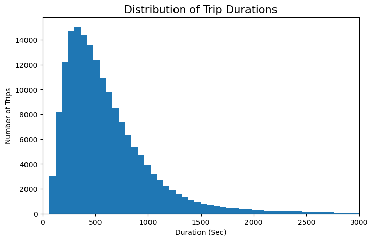

```python
# setting bins
binsize = 60
bins = np.arange(61, bikedf.duration_sec.max()+binsize, binsize)

# plotting
plt.figure(figsize=[8, 5])
plt.hist(data = bikedf, x = 'duration_sec', bins = bins);
plt.title('Distribution of Trip Durations', size = 15)
plt.xlabel('Duration (Sec)')
plt.ylabel('Number of Trips')
# set limits to get a better display of the distribution
plt.xlim([0, 3000]);
```

The plot is skewed to the right showing that trips that take longer are less frequent.

```python
# explore the distribution farther by changing xscale to log
np.log10(bikedf['duration_sec'].describe())
```

```
count    5.242919
mean     2.847574
std      3.215427
min      1.785330
25%      2.509203
50%      2.707570
75%      2.897077
max      4.927103
Name: duration_sec, dtype: float64
```

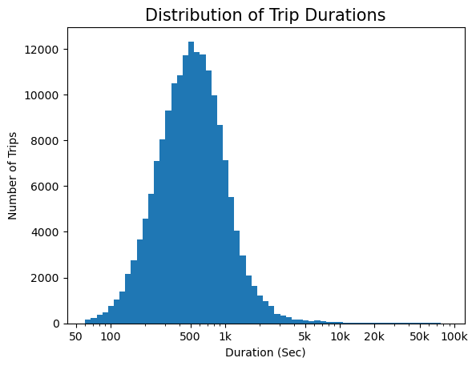

```python
# Set the scale to a log to get an even better outlook of the distribution
log_binsize = 0.05
bins = 10 ** np.arange(1.78, np.log10(bikedf['duration_sec'].max())+log_binsize, log_binsize)

plt.hist(data = bikedf, x = 'duration_sec', bins = bins)
plt.title('Distribution of Trip Durations', size = 15)
plt.xlabel('Duration (Sec)')
plt.ylabel('Number of Trips')
plt.xscale('log')
# set the appropriate ticks and labels
plt.xticks([50, 1e2, 5e2, 1e3, 5e3, 1e4, 2e4, 5e4, 1e5], [50, '100', '500', '1k', '5k', '10k', '20k', '50k', '100k']);
```

The most frequent trips take around 500 seconds.

### What is the distribution of member age?

```python
# gives the general overview of age in detail
bikedf.age.describe()
```

```
count    174952.000000
mean         34.196865
std          10.118731
min          18.000000
25%          27.000000
50%          32.000000
75%          39.000000
max         141.000000
Name: age, dtype: float64
```

```python
# to get the total number of ages greater than 95 years
bikedf.age.loc[bikedf.age >= 95].sum()
```

```
8849
```

It is highly unlikely to have ages above 95 years participating in bike rides. It is therefore logical to do away with this invalid data.

```python
# Query the dataframe to get rid of invalid ages
bikedf = bikedf.query('age <= 95')
bikedf.shape
```

```
(174877, 9)
```

```python
# test that the ages are successfully dropped
bikedf.age.loc[bikedf.age >= 95].sum()
```

```
0
```

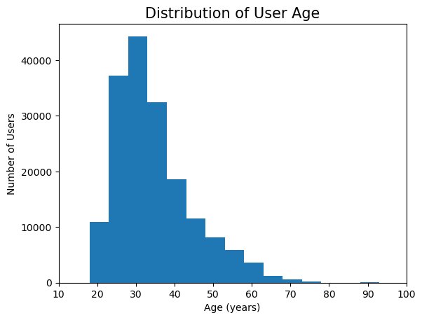

```python
# setting bins
binsize = 5
bins = np.arange(18, bikedf.age.max()+binsize, binsize)

# plotting
plt.hist(data = bikedf, x = 'age', bins = bins)
plt.title('Distribution of User Age', size = 15)
plt.xlabel('Age (years)')
plt.ylabel('Number of Users')
plt.xticks([10, 20, 30, 40, 50, 60, 70, 80, 90, 100],
          ['10', '20', '30', '40', '50', '60', '70', '80', '90', '100']);
```

### What are the common end and start stations?

#### Start stations

```python
# 10 Most commmon start stations
bikedf.start_station_name.value_counts().head(10)
```

```
Market St at 10th St                                         3649
San Francisco Caltrain Station 2  (Townsend St at 4th St)    3406
Berry St at 4th St                                           2951
Montgomery St BART Station (Market St at 2nd St)             2709
Powell St BART Station (Market St at 4th St)                 2620
San Francisco Caltrain (Townsend St at 4th St)               2572
San Francisco Ferry Building (Harry Bridges Plaza)           2540
Howard St at Beale St                                        2216
Steuart St at Market St                                      2191
Powell St BART Station (Market St at 5th St)                 2144
Name: start_station_name, dtype: int64
```

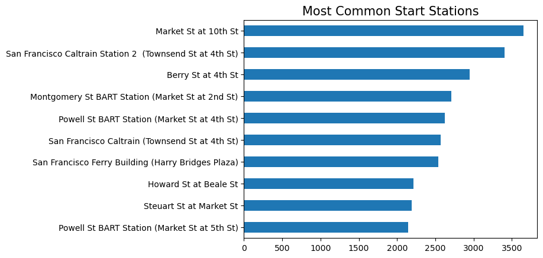

```python
plt.title('Most Common Start Stations', fontsize=15)
bikedf.start_station_name.value_counts(ascending = True).tail(10).plot.barh();
```

#### End station

```python
# 10 Most common end stations
bikedf.end_station_name.value_counts().head(10)
```

```
San Francisco Caltrain Station 2  (Townsend St at 4th St)    4621
Market St at 10th St                                         3709
Montgomery St BART Station (Market St at 2nd St)             3460
San Francisco Ferry Building (Harry Bridges Plaza)           3151
San Francisco Caltrain (Townsend St at 4th St)               2860
Powell St BART Station (Market St at 4th St)                 2854
Berry St at 4th St                                           2782
The Embarcadero at Sansome St                                2341
Steuart St at Market St                                      2264
Powell St BART Station (Market St at 5th St)                 2153
Name: end_station_name, dtype: int64
```

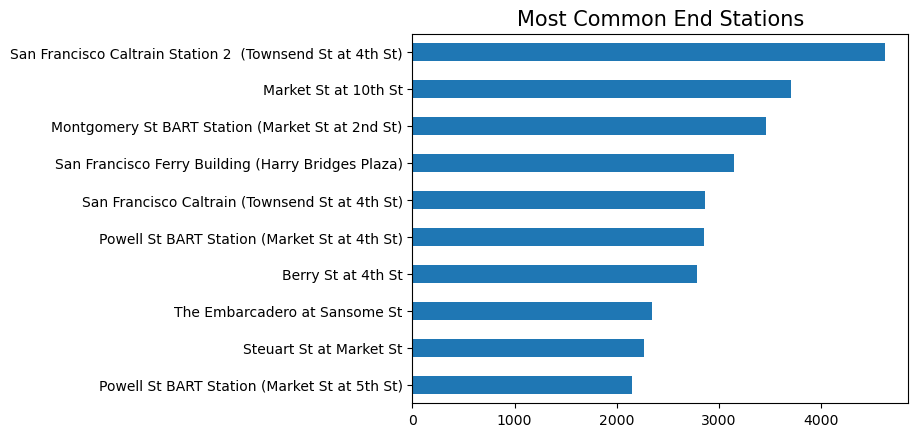

```python
plt.title('Most Common End Stations', fontsize=15)
bikedf.end_station_name.value_counts(ascending=True).tail(10).plot.barh();
```

From the above two plots it is evident that the most commmon start start stations are also the most common end stations.

### What is the distribution of user types?

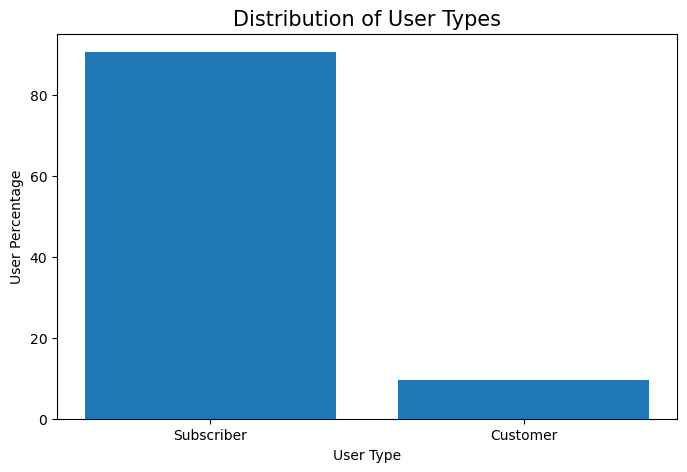

```python
plt.figure(figsize=[8,5])
plt.bar(x = bikedf.user_type.value_counts().keys(), height = bikedf.user_type.value_counts(normalize = True).mul(100))
plt.title('Distribution of User Types', size = 15)
plt.xlabel('User Type')
plt.ylabel('User Percentage');
```

From the above plot we see that only about 10% of bike users are customers while the rest are subsdribers.

```python
# Distinct percentages of each user type
bikedf.user_type.value_counts(normalize = True).mul(100)
```

```
Subscriber    90.529915
Customer       9.470085
Name: user_type, dtype: float64
```

### How is gender distributed?

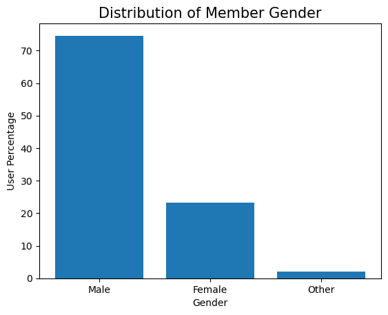

```python
plt.bar(x = bikedf.member_gender.value_counts().keys(), height = bikedf.member_gender.value_counts(normalize = True).mul(100))
plt.title('Distribution of Member Gender', size = 15)
plt.xlabel('Gender')
plt.ylabel('User Percentage');
```

From the above plot we deduce that males were the most proactive in bike riding, having a percentage of greater than 70.

```python
# Distinct percentages of male, female and other genders
bikedf.member_gender.value_counts(normalize = True).mul(100)
```

```
Male      74.589569
Female    23.325537
Other      2.084894
Name: member_gender, dtype: float64
```

### What is the distribution of bike shares?

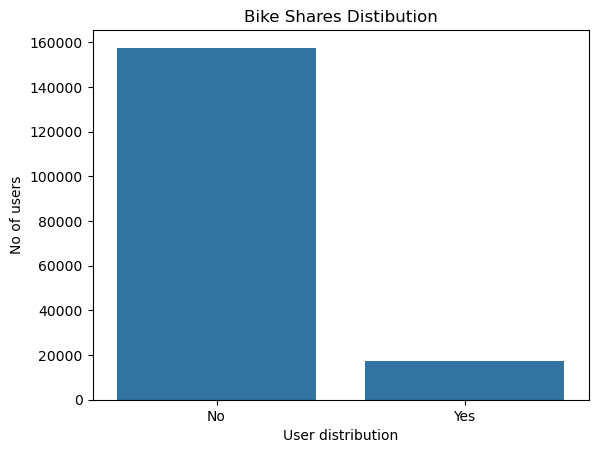

```python
base_color = sb.color_palette()[0]
plot = sb.countplot(data=bikedf, x='bike_share_for_all_trip', color = base_color)

plt.xlabel('User distribution')
plt.ylabel('No of users')
plt.title('Bike Shares Distibution');
```

```python
# Distinct bike share percentages
bikedf.bike_share_for_all_trip.value_counts(normalize = True).mul(100)
```

```
No     90.096468
Yes     9.903532
Name: bike_share_for_all_trip, dtype: float64
```

### Discuss the distribution(s) of your variable(s) of interest. Were there any unusual points? Did you need to perform any transformations?

> My variable of interest was the distribution of trip duration. I set x limits to cover 0-3000 seconds in order to get a clear view of the distribution that was initially conventrated on a small area. I also applied log scale to the histogram to get a more widespread distribution. Majority of users take approximately 500 seconds to make a trip.

### Of the features you investigated, were there any unusual distributions? Did you perform any operations on the data to tidy, adjust, or change the form of the data? If so, why did you do this?

> The ages above 95 years were invalid, since we don't expect such users to be involved in bike riding I removed this data.

## Bivariate Exploration

### What is the correlation between age and trip duration

```python
# serves as a reminder of columns to use in plotting
bikedf.columns
```

```
Index(['duration_sec', 'start_time', 'end_time', 'start_station_name',
       'end_station_name', 'user_type', 'member_gender',
       'bike_share_for_all_trip', 'age'],
      dtype='object')
```

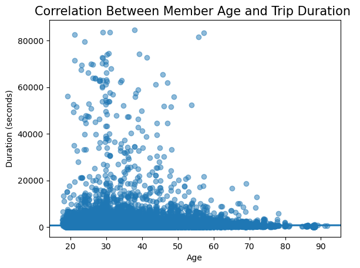

```python
# age duration correlation
sb.regplot(data = bikedf, x = 'age', y = 'duration_sec', truncate=False, x_jitter=0.3, scatter_kws={'alpha':5/10});
plt.title('Correlation Between Member Age and Trip Duration ', size = 15)
plt.xlabel('Age')
plt.ylabel('Duration (seconds)');
```

Member age and trip duration as seen above have a negative correlation such that the older the member is the less time they will take in their trips. It is also evident that majority of the members no matter the age preferred taking short trips.

### What is the relationship between trip duration and gender?

```python
# convert trip duration to seconds
bikedf['duration_min'] = bikedf['duration_sec']/60
# test to view changes, there should be a new column, duration_min
bikedf.head()
```

|  | duration_sec | start_time | end_time | start_station_name | end_station_name | user_type | member_gender | bike_share_for_all_trip | age | duration_min |
| --- | --- | --- | --- | --- | --- | --- | --- | --- | --- | --- |
| 0 | 52185 | 2019-02-28 17:32:10.145 | 2019-03-01 08:01:55.975 | Montgomery St BART Station (Market St at 2nd St) | Commercial St at Montgomery St | Customer | Male | No | 35 | 869.750000 |
| 2 | 61854 | 2019-02-28 12:13:13.218 | 2019-03-01 05:24:08.146 | Market St at Dolores St | Powell St BART Station (Market St at 4th St) | Customer | Male | No | 47 | 1030.900000 |
| 3 | 36490 | 2019-02-28 17:54:26.010 | 2019-03-01 04:02:36.842 | Grove St at Masonic Ave | Central Ave at Fell St | Subscriber | Other | No | 30 | 608.166667 |
| 4 | 1585 | 2019-02-28 23:54:18.549 | 2019-03-01 00:20:44.074 | Frank H Ogawa Plaza | 10th Ave at E 15th St | Subscriber | Male | Yes | 45 | 26.416667 |
| 5 | 1793 | 2019-02-28 23:49:58.632 | 2019-03-01 00:19:51.760 | 4th St at Mission Bay Blvd S | Broadway at Kearny | Subscriber | Male | No | 60 | 29.883333 |

```python
bikedf['duration_min'].describe()
```

```
count    174877.000000
mean         11.733767
std          27.375477
min           1.016667
25%           5.383333
50%           8.500000
75%          13.150000
max        1409.133333
Name: duration_min, dtype: float64
```

```
(-93.52940841159541, 1485.6725653561928)
```

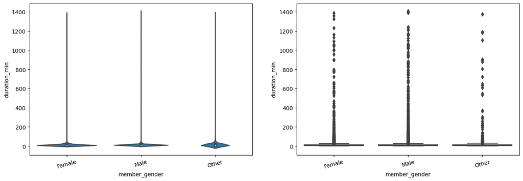

```python
plt.figure(figsize = [16, 5])
base_color = sb.color_palette()[0]

# LEFT plot: violin plot
plt.subplot(1, 2, 1)
#Let's return the axes object
ax1 = sb.violinplot(data=bikedf, x='member_gender', y='duration_min', color=base_color)
plt.xticks(rotation=15);

# RIGHT plot: box plot
plt.subplot(1, 2, 2)
sb.boxplot(data=bikedf, x='member_gender', y='duration_min', color=base_color)
plt.xticks(rotation=15);
plt.ylim(ax1.get_ylim()) # set y-axis limits to be same as left plot
```

Since the plots are concentrated on the shorter durations, signifying that the longer durations that occured are moslty outliers and very sparse, I will set y limits to zoom into the significant duration time.

```
(-10.0, 100.0)
```

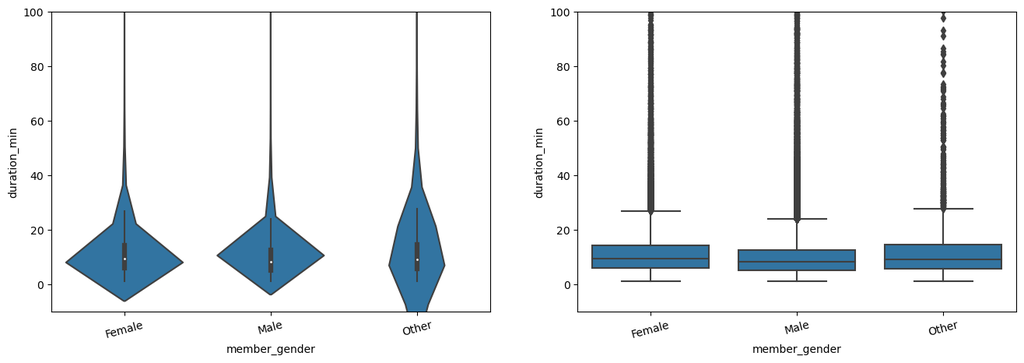

```python
# setting y limits
plt.figure(figsize = [16, 5])
base_color = sb.color_palette()[0]

# LEFT plot: violin plot
plt.subplot(1, 2, 1)
#Let's return the axes object
ax1 = sb.violinplot(data=bikedf, x='member_gender', y='duration_min', color=base_color)
plt.xticks(rotation=15);
plt.ylim([-10, 100])

# RIGHT plot: box plot
plt.subplot(1, 2, 2)
sb.boxplot(data=bikedf, x='member_gender', y='duration_min', color=base_color)
plt.xticks(rotation=15);
plt.ylim(ax1.get_ylim()) # set y-axis limits to be same as left plot
```

It appears that on average females spend more time in their trips than men.

### What is the relationship between trip duration and user type?

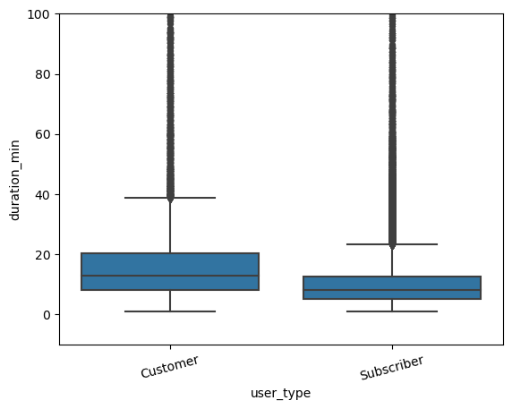

```python
sb.boxplot(data=bikedf, x='user_type', y='duration_min', color=base_color)
plt.xticks(rotation=15)
plt.ylim([-10, 100]);
```

On average customers spend more time in their bike trips as compared to subscribers.

### What is the relationship between trip duration and trip bike shares?

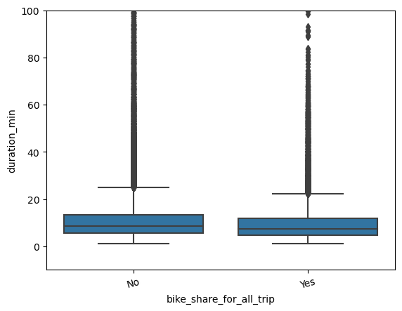

```python
sb.boxplot(data=bikedf, x='bike_share_for_all_trip', y='duration_min', color=base_color)
plt.xticks(rotation=15)
plt.ylim([-10, 100]);
```

On average those not sharing their bikes during the trips spend slightly more time.

### Other relationships of interest include:

#### Relationship between bikeshares and age

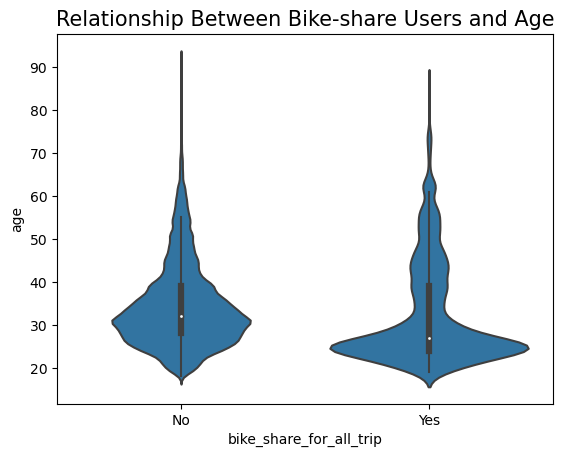

```python
# use a violin plot to view age distribution among bike shares.
sb.violinplot(data=bikedf, x='bike_share_for_all_trip', y='age', color=base_color)
plt.title('Relationship Between Bike-share Users and Age', size =15);
```

The concentration of members sharing their bikes is mostly between 20 and 30 years while those not sharing their are more widespread ranging between 20 t0 40 years.

#### Relatioship between user type and age

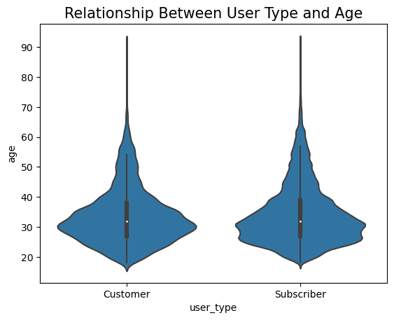

```python
# use a violin plot to view the age distribution among user types
sb.violinplot(data=bikedf, x='user_type', y='age', color=base_color)
plt.title('Relationship Between User Type and Age', size =15);
```

It appears that the concentration of both customers and subscribers is around age 20 to 40.

#### What number of each user type engage in bike sharing?

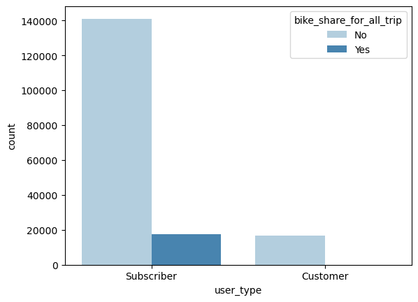

```python
sb.countplot(data = bikedf, x = 'user_type', hue = 'bike_share_for_all_trip', order=bikedf.user_type.value_counts().index,
             palette = 'Blues');
```

It appears that no customer engaged in bike sharing, they probably are not allowed. Only a small percentage of subscribers engage in the same.

#### What is the distibution of gender types among the different user types?

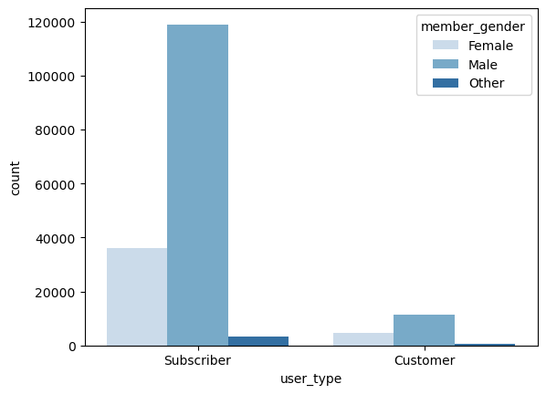

```python
sb.countplot(data = bikedf, x = 'user_type', hue = 'member_gender',order=bikedf.user_type.value_counts().index,
             palette = 'Blues');
```

It is evident that in both categories male members are dominant followed by female members then the other gender.

### Talk about some of the relationships you observed in this part of the investigation. How did the feature(s) of interest vary with other features in the dataset?

> In the relationship between trip duration and age, it is clearly observable that members of age 20-40 are more proactive such that they dominate both in short durations and long durations. Above age 50 there's sudden decline in long duration and a steady decline in the short durations.  
> In the ralationship between trip duration and gender, it is observed that on average female members spend more time in their trips than male mebers.  
> Customers spend way much time in their trips as compared to subscribers.

## Multivariate Exploration

```python
# reminder of columns to use in plotting
bikedf.columns
```

```
Index(['duration_sec', 'start_time', 'end_time', 'start_station_name',
       'end_station_name', 'user_type', 'member_gender',
       'bike_share_for_all_trip', 'age', 'duration_min'],
      dtype='object')
```

#### Functions to utilize in this section

```python
# scatter plot function
def plot_correlation(data, x, y, title, xlabel, ylabel, x_jitter = 0, hue = None, aspect = 0, hue_order = None, fit_reg = False):
    g =sb.FacetGrid(data = data, hue = hue,
                hue_order = hue_order, aspect = aspect)
    g = g.map(sb.regplot, x, y, x_jitter = x_jitter, fit_reg = fit_reg)
    g.add_legend()
    plt.title(title, size = 15)
    plt.xlabel(xlabel)
    plt.ylabel(ylabel)
```

```python
# poitplot function
def point_plot(data, x, y, ylabel, title, hue, palette, linestyles, dodge):
    sb.pointplot(data = data, x=x, y=y, hue=hue, palette = palette, dodge =dodge, linestyles = linestyles)
    plt.ylabel(ylabel)
    plt.title(title, size = 15)
```

### What is the correlation of age with trip duration for each user type?

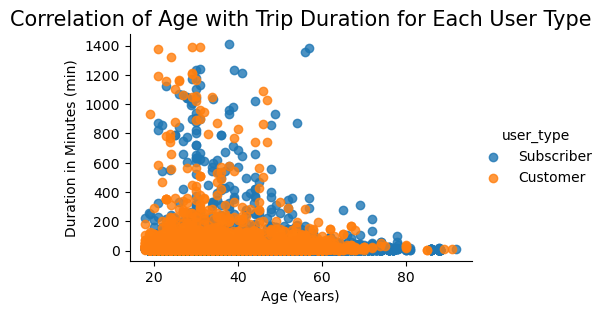

```python
plot_correlation(data = bikedf, x = 'age', y = 'duration_min', x_jitter = 0.04,
                hue = 'user_type', hue_order = ['Subscriber', 'Customer'], aspect = 1.5,
                title = 'Correlation of Age with Trip Duration for Each User Type',
                xlabel = 'Age (Years)', ylabel = 'Duration in Minutes (min)');
```

The correlation of trip duration for both subscribers appears to be similar.

### What is the correlation of age with trip duration for the bike shares?

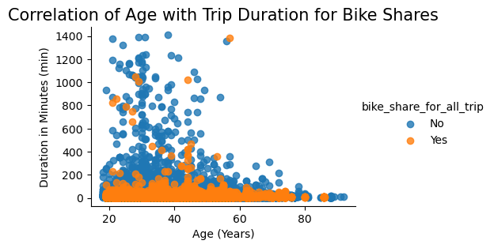

```python
plot_correlation(data = bikedf, x = 'age', y = 'duration_min', x_jitter = 0.04,
                hue = 'bike_share_for_all_trip', hue_order = ['No', 'Yes'], aspect = 1.5,
                title = 'Correlation of Age with Trip Duration for Bike Shares',
                xlabel = 'Age (Years)', ylabel = 'Duration in Minutes (min)');
```

The correlation of trip duration with age appears to be similar for both both bike shares. However, those who do not share their bikes appear to be taking the longer duration trips.

### What is the correlation of member age with trip duration for each gender?

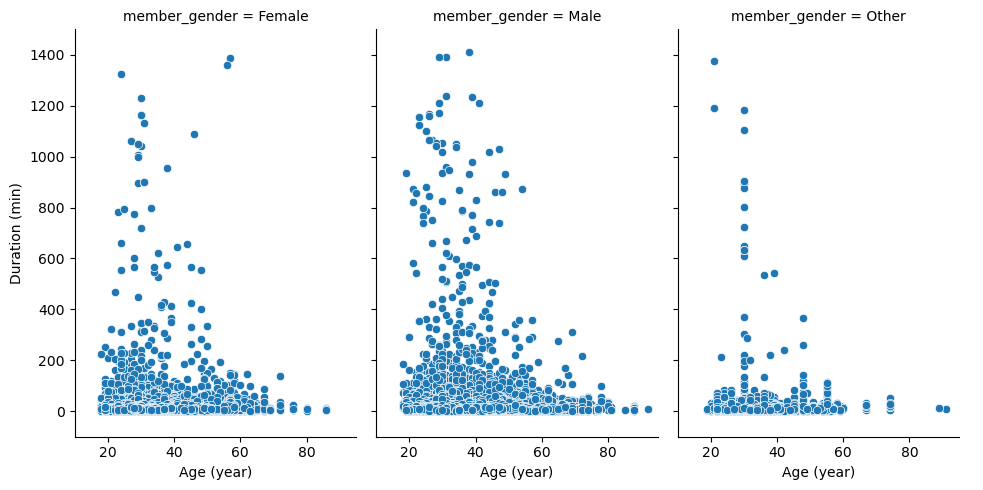

```python
plt.figure(figsize=[10,15])
g = sb.FacetGrid(data = bikedf, col = 'member_gender', col_wrap = 3, height = 5,
                  aspect =0.65, xlim = [10, 95], ylim = [-100, 1500])
g.map_dataframe(sb.scatterplot, 'age', 'duration_min', alpha= None)
g.set_axis_labels('Age (year)', 'Duration (min)')
g.add_legend();
```

It is evident that across all genders, members between age 20 and 50 take longer time in their trips. The male and female plots are similar in terms of the reduction in duration time with age while for other gender there is no definite reduction in trip duration with age, only a specific age around 30 years seems to be having longer durations than the rest.

### Trip duration across gender and bike shares

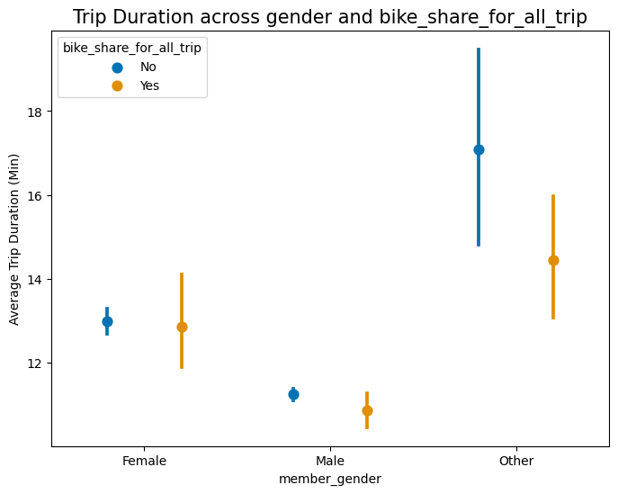

```python
plt.figure(figsize = [8,6])
point_plot(data = bikedf, x = 'member_gender', y = 'duration_min',
           title = 'Trip Duration across gender and bike_share_for_all_trip',
           ylabel = 'Average Trip Duration (Min)',
           hue = 'bike_share_for_all_trip', palette = 'colorblind', linestyles = '', dodge = 0.4);
```

### Trip duration across gender and user types

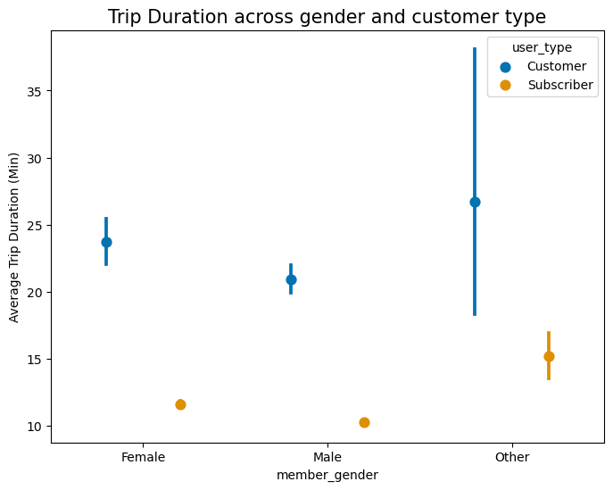

```python
plt.figure(figsize = [8,6])
point_plot(data = bikedf, x = 'member_gender', y = 'duration_min',
           title = 'Trip Duration across gender and customer type',
           ylabel = 'Average Trip Duration (Min)',
           hue = 'user_type', palette = 'colorblind', linestyles = '', dodge = 0.4);
```

- Among the other gender both customers and subsribers took the longest trip durations, followed by female members then male members.
- Customers in each gender averagely took the longest durations.

### Talk about some of the relationships you observed in this part of the investigation. Were there features that strengthened each other in terms of looking at your feature(s) of interest?

- There were similar trends of correlation between member age and trip duration for both user types and bike shares, that is a negative correlation. However, it appears that majority of those who did not share their bikes had the longest trip durations.
- Looking at gender trip durations it's evident that the other gender spends mote time in their trips followed by female then male genders.
- Customers on average take more time in their trips across all genders.

### Were there any interesting or surprising interactions between features?

```python
# convert the dataframe to csv for the next part of the exploration
bikedf.to_csv('fordgobike_updated_tripdata.csv', index = False)
```